# Divvy Bike Project

Rémy Garnier - Camille Palmier

28 février 2018

# I- Introduction

Dans le cadre du cours *Data Mining*, nous avons choisi des données temporelles sur le système de partage de vélos de la ville de Chicago. Le but de ce projet est de manipuler des données en grande dimension (nous avons récupéré environ 13 millions de données) et de construire des modèles de prédiction performants.

Notre rapport s’organise de la manière suivante : nous présentons dans une première partie les données brutes puis dans une seconde les données transformées. En effet, un enjeu important a été de transformer les données dans un format compatible avec nos envies de prédiction et nos modèles. Une troisième partie portera sur les modèles que nous avons utilisé pour la prédiction. Dans cette dernière partie, nous parlerons du découpage Tendance/Saisonnalité de nos séries, des modèles additifs généralisés (*gam*) et des modèles d’arbre (*Random Forest*).

Dans le cadre du projet, nous avons construit un package R :

```r
library("DivvyBikeProject")
```

La fonction de ce package est de regrouper toutes les manipulations que nous avons apporté sur les données : il permet donc de passer des données brutes (directement téléchargeable sur internet, voir **II**) aux différents jeux de données utilisés dans nos modèles. Nous présenterons les fonctions présentes dans notre package au fur et à mesure des deux premières parties.

# II - Présentation des données

### Le jeu de données

Divvy est le système de partage de vélos de la ville de Chicago, avec 6 000 vélos disponibles à plus de 570 stations à travers Chicago et Evanston. Divvy, comme les autres systèmes de vélos de libre-service, se compose d’une flotte de vélos qui sont enfermés dans un réseau de stations d’accueil dans toute la région. Les vélos peuvent être déverrouillés à partir d’une station et renvoyés à n’importe quelle autre station du système. Divvy offre aux résidents et aux visiteurs une option de transport pratique pour se déplacer et explorer Chicago.

Divvy est un programme du Département des Transports de Chicago (CDOT), qui possède les vélos, les stations et les véhicules de la ville. Le financement initial du programme provenait de subventions fédérales pour des projets qui favorisent le redressement économique, réduisent la congestion du trafic et améliorent la qualité de l’air, ainsi que des fonds supplémentaires provenant du programme de financement des augmentations d’impôt de la Ville. En 2016, Divvy s’est étendu à la banlieue voisine d’Evanston grâce à une subvention de l’État de l’Illinois.

Sur le site de Divvy, les [données](https://www.divvybikes.com/system-data) sur les trajets et les stations sont disponibles au public. Tous les ans, deux jeux de données sont publiés : un premier allant de janvier à juin et un second allant de juillet à décembre.

Chaque trajet à vélo est anonymisé et comprend :

- Jour et heure du début du voyage
- Jour et heure de la fin du voyage
- Station de départ
- Station d’arrivée
- Type d’utilisateur (membre, tour unique ou passe d’exploration)
- Si un membre voyage, le sexe et l’année de naissance sont inclus

Exemple de 5 trajets réalisés en 2014 :

```
##   trip_id       starttime        stoptime bikeid tripduration
## 1 2355134 6/30/2014 23:57   7/1/2014 0:07   2006          604
## 2 2355133 6/30/2014 23:56   7/1/2014 0:00   2217          263
## 3 2355130 6/30/2014 23:33 6/30/2014 23:35   2798          126
## 4 2355129 6/30/2014 23:26   7/1/2014 0:24    173         3481
## 5 2355128 6/30/2014 23:16 6/30/2014 23:26    173          638
##   from_station_id           from_station_name to_station_id
## 1             131   Lincoln Ave & Belmont Ave           303
## 2             282     Halsted St & Maxwell St            22
## 3             327 Sheffield Ave & Webster Ave           225
## 4             134    Peoria St & Jackson Blvd           194
## 5             320    Loomis St & Lexington St           134
##            to_station_name   usertype gender birthyear
## 1  Broadway & Cornelia Ave Subscriber   Male      1988
## 2       May St & Taylor St Subscriber   Male      1992
## 3 Halsted St & Dickens Ave Subscriber   Male      1993
## 4     State St & Wacker Dr Subscriber Female      1988
## 5 Peoria St & Jackson Blvd Subscriber Female      1988
```

En plus des deux fichiers sur les trajets à vélo, nous pouvons récupérer tous les ans une table sur les stations. Pour chaque station, nous avons :

- Identifiant
- Nom
- Latitude
- Longitude
- Capacité (nombre de vélos que la station peut supporter)
- Date de mise en service

Les 5 premières lignes de la table des stations de 2014 :

```
##    id                         name latitude longitude dpcapacity
## 1  43 Michigan Ave & Washington St 41.88389 -87.62465         43
## 2  44       State St & Randolph St 41.88473 -87.62773         27
## 3  33      State St & Van Buren St 41.87718 -87.62784         27
## 4 199       Wabash Ave & Grand Ave 41.89174 -87.62694         15
## 5  51       Clark St & Randolph St 41.88458 -87.63189         31
##   online date
## 1  2013-06-16
## 2  2013-06-16
## 3  2013-06-25
## 4  2013-08-10
## 5  2013-06-17
```

### Analyses descriptives des données

Nombre de trajets et stations par année.

| Année | Stations | Trajets |
| --- | --- | --- |
| 2013 | 300 | 759 788 |
| 2014 | 300 | 2 454 634 |
| 2015 | 474 | 3 183 439 |
| 2016 | 581 | 3 595 383 |
| 2017 | 585 | 3 829 014 |
|  |  | Total : 13 822 258 |

Les vélos ont été mis en service en juin 2013 d’où un nombre de trajets plus faible. Ces chiffres nous montre une augmentation du nombre de trajets sur le réseau et une augmentation du réseau lieu même au cours du temps. C’est entre 2014 et 2015 que ces augmentations sont les plus importantes avec environ 30% de trajets supplémentaires et 174 nouvelles stations.

L’extention du service à la banlieue d’Evanston en 2016 représente la création de quatre nouvelles bornes dans le réseau.

### Visualisation géographique

Grâce aux informations présentes dans la table *Station*, nous pouvons visualiser l’emplacement des stations vélos dans la ville de Chicago.

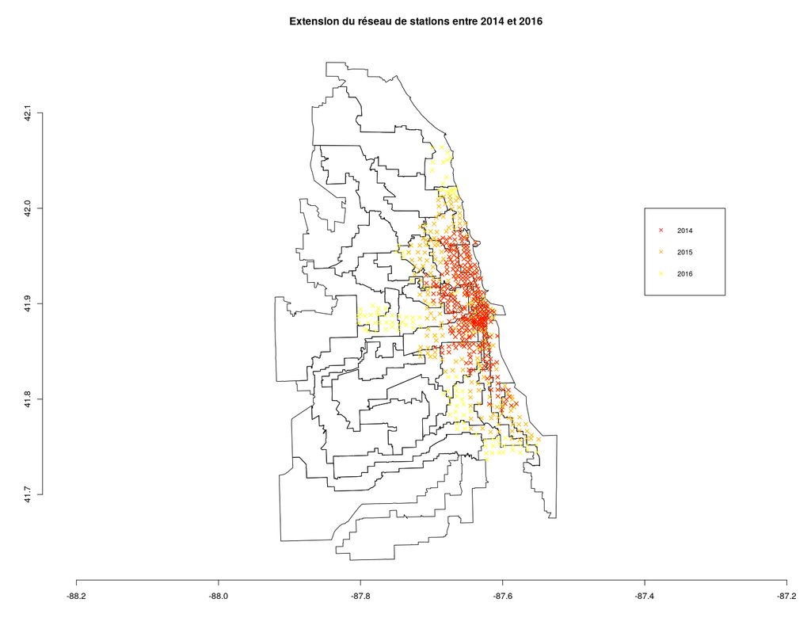

Sur ce graphique, nous n’avons pas rajouté les stations de 2013 et de 2017 car il y a peu de changements entre 2013 et 2014 et entre 2016 et 2017.

Nous pouvons voir que les stations vélos ont dans un premier temps été réparti dans le centre puis elles vont ensuite s’étendre vers les banlieues.

Nous nous sommes également rendu compte que certaines stations se déplaçaient de quelques mètres d’une année sur l’autre ou changer de noms. Ces deux observations justifient en partie l’agrégation spatiale fait par la suite.

Regardons maintenant la fréquentation des stations en 2016 :

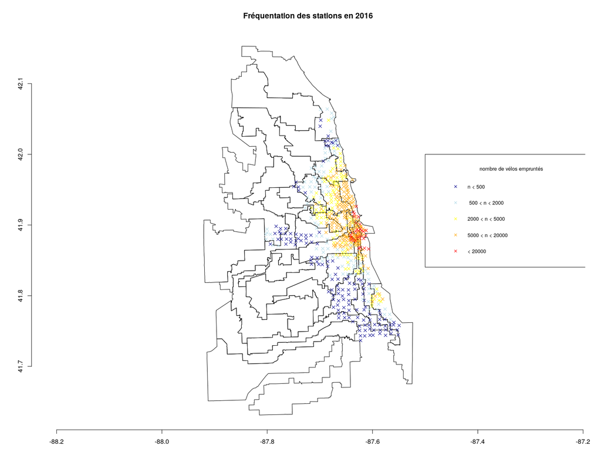

Nous remarquons sur ce graphique, que les vélos les plus utilisés sont surtout ceux du centre ville. Aux vues des profils de nos trajets, il semble que le centre regroupe écoles et lieux de travail (voir profil d’une journée plus bas).

Nous pouvons voir qu’il y a un fort écart entre les stations les moins utilisées (moins de 200 vélos empruntés par an) et les stations les plus utilisées (jusqu’à 92 000 vélos empruntés par an).

# III - Transformation des données

Nous présenterons dans cette partie les manipulations que nous avons effectué sur les données. Cette partie représente une bonne partie de notre travail, elle est donc centrale. Les trois paragraphes suivants permettent de se rendre compte d’une partie des problèmes “simples” que ous avons rencontré et qui a motivé une transformation des données.

Les données que l’on trouve sur le site de Divvy ne sont pas divisées de la même façon selon les années. Par exemple, pour 2014, nous avons un fichier contenant toutes les données de janvier à juin (Q1Q2) mais pour 2016, nous avons un fichier avec Q1 (janvier à mars) puis un fichier pour avril, un autre pour juin et un dernier pour juillet. Dans notre package, nous prenons en compte les spécificités de chaque année pour homogénéiser.

A l’intérieur de chaque fichier, on trouve des différences au niveau des noms des variables (exemple : ‘-’ une année et ’_’ une autre).

Un autre problème que l’on a rencontré se trouve au niveau des stations. Nous avons déjà remarqué plus haut que certaines changent de nom et d’autre de place au cours du temps.

Nous avons réalisé plusieurs agrégations : une agrégation temporelle et une agrégation spatiale. Ces agrégations ont été motivé d’une part par les problèmes précédemment décrit et d’autre part par une volonté de réduire la dimension de notre jeu de données (13.5 millions de trajets et une dizaine de variables).

### Agrégation temporelle

Nous avons compté, pour chaque station, le nombre de vélos entrant (**nbE**) et le nombre de vélos sortant (**nbS**) à chaque heure. L’agrégation au pas horaire nous a paru pertinente car elle permet de garder une maille temporelle assez fine tout en réduisant la dimensionalité de manière efficace.

Ce choix d’agrégation a conditionné nos séries d’intérêt puisque nous avons perdu des informations telles que les informations sur les utilisateurs ou encore le détail précis de chaque trajet.

L’agrégation temporelle (ainsi que la standardisation du format des données) se fait en utilisant la fonction **aggregateData** du package.

### Agrégation spatiale

Le fait que de nouvelles stations s’ouvrent constamment, ainsi que le fait qu’elles sont parfois déplacées, nous a conduit à grouper les données géographiquement. Ainsi, nous supposons que des stations spatialement proche se comportent de la même façon.

Pour gérer les données géographiques, nous avons utilisé les packages R *rgdal* et *raster*. Étant donné un découpage spatial de la ville de Chicago contenue dans le Large SpatialPolygonDataFrame *area*, ainsi qu’un fichier *data* regroupant les données agrégées temporellement sur les *stations*, nous obtenons une agrégation spatiale via la fonction **groupByGeospatialData(data, area, stations, year, save_data = FALSE)**

Pour nos tests, nous avons choisi le découpage géographique par circonscriptions législatives pour la chambre basse de l’Illinois, obtenue sur le site du [recensement](https://www.census.gov/) américain. Ce découpage n’est objectivement pas très bon, notamment à cause de la pratique du [gerrymandering](https://fr.wikipedia.org/wiki/Gerrymandering). En effet, la forme des circonscriptions est généralement tortueuse (voir carte plus haut) et regroupe des populations différentes pour des considérations électorales. Cependant, il s’agit du seul regroupement à la bonne échelle que nous avons pu trouver. Par ailleurs, comme on le verra, ce découpage est déjà informatif.

On peut ainsi regrouper les stations dans une vingtaine de régions géographiques différentes qui comportent chacune en moyenne 24 stations (avec un écart type de 18).

### Ajouts de variables explicatives

Ces variables sont ajoutées respectivement par les fonctions **getMeteo** et **getSpecialDays**.

L’ensembles des manipulations décrites dans les trois derniers paragraphes ont été regroupées dans la fonction **BuildDataSet**.

Voici un extrait de nos données finales :

```
##                   Time district        Day Hour nbE nbS diff nb_stations
## 55 2015-01-01 02:00:00       24 2015-01-01    2   0   0    0           1
## 56 2015-01-01 02:00:00       25 2015-01-01    2   0   0    0          25
## 57 2015-01-01 02:00:00       26 2015-01-01    2   0   0    0          40
## 58 2015-01-01 02:00:00       32 2015-01-01    2   0   0    0           3
## 59 2015-01-01 02:00:00       39 2015-01-01    2   0   0    0          11
## 60 2015-01-01 02:00:00       40 2015-01-01    2   0   0    0          16
##    temp pluvio dow  weekday
## 55 -7.2      0   8 NewYears
## 56 -7.2      0   8 NewYears
## 57 -7.2      0   8 NewYears
## 58 -7.2      0   8 NewYears
## 59 -7.2      0   8 NewYears
## 60 -7.2      0   8 NewYears
```

### Définition de nos séries d’intérêt

Nous avons proposé $3$ série d’intérêt différentes :

- **nbEstat** : le nombre moyen de vélos par station entrant dans la région à une heure donnée par district
- **nbSstat** : le nombre moyen de vélos par station sortant de la région à une heure donnée par district
- **diff** = nbEstat - nbStat : la différence entre le nombre de vélos entrant et sortant de chaque région par heure et par district

Nous estimons que cette dernière statistique est la plus utile, car elle permet de déterminer comment les vélos doivent être déplacer entre les différentes régions afin de s’assurer que les stations ne soient jamais soit complètement vides, soit complètement pleines.

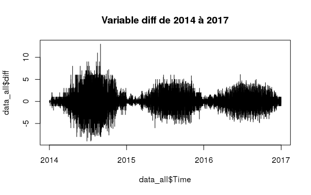

Ce premier graphique permet de visualiser la variable **diff**. La forme générale est la même quelque soit l’année : les vélos sont moins empruntés en début d’année (période hivernale - janvier/février) et c’est en été que la différence entrant/sortant est la plus importante.

Pour bien comprendre la forme de la série, intéressons-nous à *nbEstat* et *nbSstat* sur une période de temps restreinte (la deuxième semaine du mois de *juillet 2014*) et sur une seule station (la station 9). Le district 9 se situe en plein centre ville et regroupe le plus de stations.

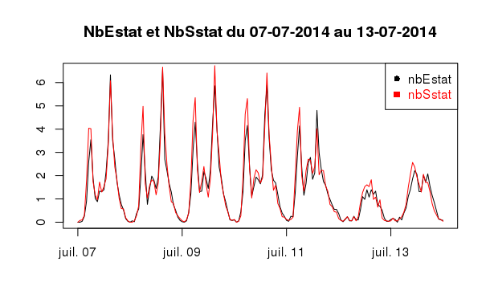

Le profil des week-end est différent, nous n’observons plus le même rythme au niveau du matin et du soir : les vélos sont plutôt utilisés pour se promener dans la ville de 10h à 18h.

Le choix de la station 9 a une influence sur les semaines. En effet, dans les districts du centre de Chicago, on peut voir que le nombre d’entrée et le nombre de sortie est quasiment similaire au cours de la journée. Cela est surement dû au fait que les personnes au coeur de la ville se déplacent entre ces grands districts et que les personnes vivant un peu plus loin du centre viennent le matin travailler.

Pour comprendre le contraste entre les districts de banlieue et les distrits du centre, le graphique suivant montre la même semaine de juillet 2014 mais pour le district 4.

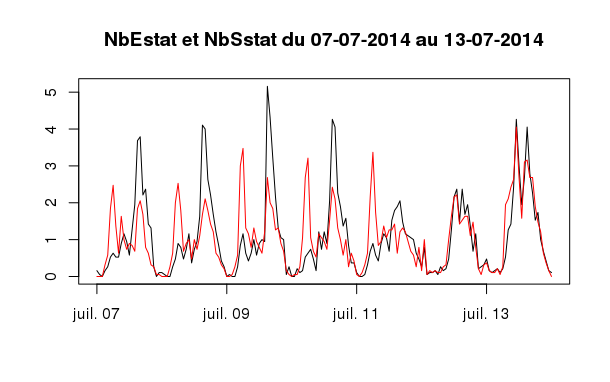

Nous pouvons supposer que les interactions avec les autres districts sont plus faibles.

Pour compléter la visualisation hebdomadaire, voici le profil d’une journée de semaine type :

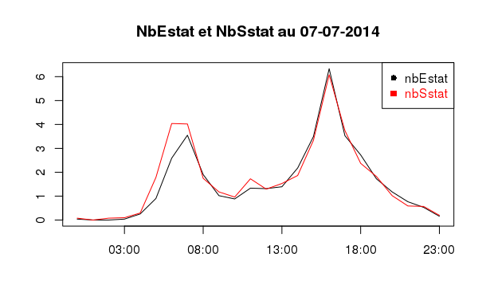

# IV - Les modèles

Nous utiliserons comme critère de perfomance le RMSE (écart-type moyen). Pour nbE_stat , la moyenne des performances est de 0.40 et l’écart type standard est de 0.96. Ces chiffres nous permettent de constater les perfomances des différents modèles que nous allons présenter.

### Tendance

Pour commencer, intéressons_nous à la tendance de nos séries. La série **diff** n’ayant pas de tendance par construction (centrée en zéro), nous allons nous concentrer sur les séries **nbEstat** et **nbSstat**.

Pour ces deux séries, nous voyons un effet multiplicatif de la tendance et de la saisonnalité qui est traduit par l’équation suivante :

**Série = Tendance * Saisonnalité Annuelle * (Saisonnalité Quotidienne + écart )**

Pour chercher la tendance, nous avons utilisé un modèle linéaire (fonction *lm*). La tendance est représentée par la droite rouge sur les deux graphiques suivants.

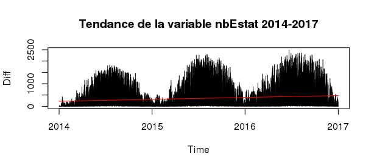

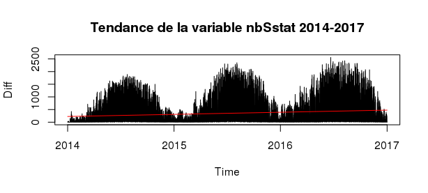

Que ce soit pour la variable **nbEstat** ou pour la variable **nbSstat**, la tendance est croissante. Nous avons vu précédemment qu’au fur et à mesure du temps, le nombre de vélos entrant ou sortant augmentait.

Les deux séries se ressemblant beaucoup, nous allons présenté uniquement les résultats pour la variable **nbEstat**.

Le graphique suivant montre la variable corrigée de sa tendance. La courbe rouge est là pour vérifier que nos données corrigées aient bien une tendance nulle.

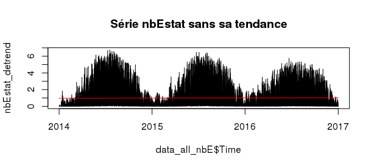

### Saisonnalité

Les visualisations graphiques semblent nous indiquer une double saisonnalité : annuelle et journalière. Pour rechercher la saisonnalité nous avons utilisé la fonction *lm* comme précédemment pour la tendance mais également les modèles additifs généralisés (*gam*). Ces deux méthodes ont aboutit au même résultat.

Nous avons commencé par la saisonnalité la plus globale, soit la saisonnalité annuelle qui est visible en rouge sur le graphique suivant :

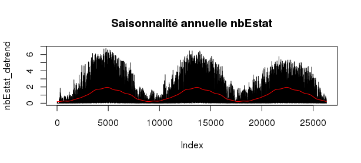

En corrigeant la variable de sa saisonnalité annuelle (en plus de sa tendance), nous obtenons le résultat suivant :

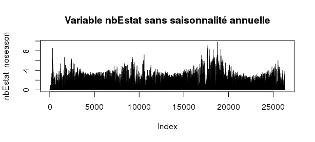

### Modèle GAM

#### Un premier modèle :

Une autre idée est d’utiliser les modèles GAM classiques afin de prédire les différentes variables d’intérêts. On procède de la façon suivante:

- On utilise d’abord les données de 2014 et 2015 comme données d’entrainementOns, et on valide le choix d’hyperparamètres en utilisant les données de 2016 comme ensemble de validation
- On utilise ensuite toutes les données de 2014 à 2016 pour prédire la variable en 2017.

Nous avons effectué quelques manipulations des données supplémentaires afin de mieux prédire :

- Nous avons trié les districts par ordre de fréquentation, afin de pouvoir obtenir un comportement monotone
- Par ailleurs, nous avons identifié les périodes les plus actives ( de 7 à 8h et de 16 à 18h en semaine ) par une variable spéciale.

Le modèle obtenu n’est pas très efficace, et on obtient un RMSE de 0.744.

#### Un second modèle :

En utilisant les mêmes hyper-paramètre que precedemment, on peut essayer de n’utiliser comme données d’entrainements que les données concernant un district donné pour prédire sur ce district. On appelle ce modèle modèle local, en opposition au modèle précédent, global. Le plus souvent, les modèles locaux sont plus efficaces pour prédire que le modèle global, mais ce n’est pas toujours le cas. Le tableau et le graphique suivant montrent différents comportements typiques (sur le graphique, les prédicitions sont en noir).

RMSE pour différents districts pour les modèles locaux et globaux

| District | Global | Local |
| --- | --- | --- |
| 2 | 0.39 | 0.13 |
| 9 | 1.00 | 0.79 |
| 12 | 1.92 | 1.18 |
| 14 | 0.31 | 0.34 |

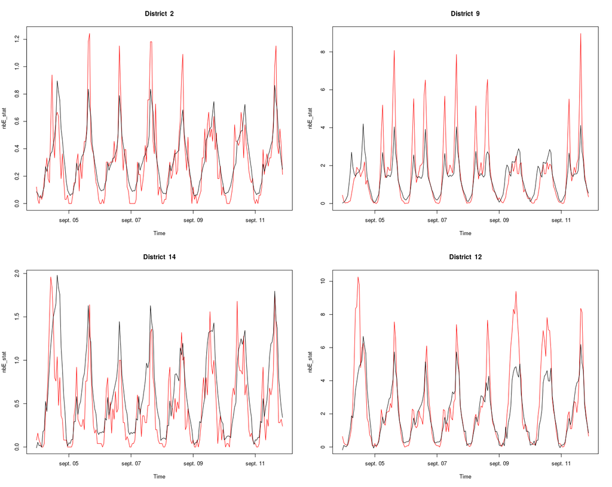

### Random Forests

Un modèle que nous avons utilisé est celui des random forests du package *Random Forests* .On utilise les données de 2014 à 2016 pour entrainer le modèle. Ce modèle est assez simple à implémenter et obtient de très bon résultats. Cependant, il est un peu couteux en temps de calcul. En effet, on obtient pour la prévision de nbE_stat un RMSE de 0.305 en utilisant 10 arbres différents. On peut observer l’efficacité de ce modèles sur différnes districts. Il semble que l’efficacité de la prévision soit très dépendante des districts considérés.

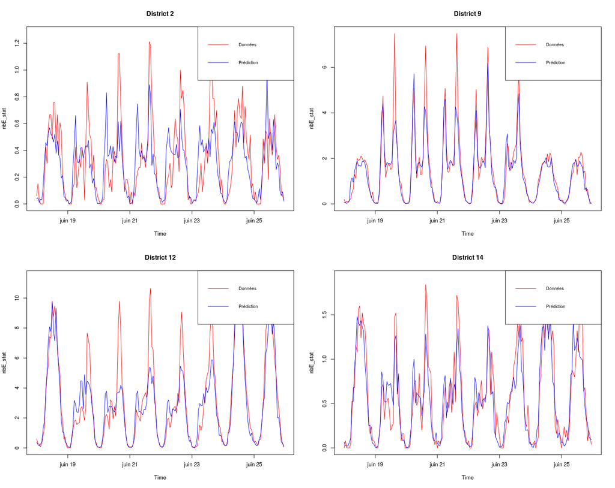

Les random forests nous permettent également d’étudier les influences des différentes variables. On peut ainsi supprimer certaines variables, et essayer de voir quelle est l’erreur sans ces variables.

RMSE pour différents modèles

| Modèle | RMSE |
| --- | --- |
| Complet | 0.305 |
| Sans Données géographiques | 0.850 |
| Sans la température | 0.487 |
| Sans le type de jours | 0.405 |
| Sans les différentes annés | 0.322 |
| Sans la pluviométrie | 0.305 |

Il semble donc que la plupart des variables soient significatives, mais pas la pluviométrie. Notons au passage que le découpage géographique semble pertinent, puisque l’écart si l’on considère que toutes les stations se comportent de manière identiques est plus important.

La encore, on peut tester la différence entre modèles locaux et globaux.

RMSE pour différents districts pour les modèles locaux et globaux

| District | Global | Local |
| --- | --- | --- |
| 2 | 0.10 | 0.08 |
| 9 | 0.53 | 0.34 |
| 12 | 0.73 | 0.52 |
| 14 | 0.14 | 0.13 |

Les modèles locaux sont encore plus efficaces que le modèles global.

# V - Conclusion

Nous remerçions Monsieur Goude pour nous avoir aider à réaliser ce projet.